# (Bike Sharing Analysis with Ford GoBike Data)

### by (Khalid AlQublan)

#### Preliminary Wrangling

> This document explores a dataset containing Ford GoBike's trip data for approximately 519700 trips in 2017.

```python
# import all packages and set plots to be embedded inline
import numpy as np
import pandas as pd
import matplotlib.pyplot as plt
import seaborn as sb
import datetime
%matplotlib inline
```

> Load in your dataset and describe its properties through the questions below. Try and motivate your exploration goals through this section.

```python
# load in the dataset into a pandas dataframe
df_gobike = pd.read_csv('2017-fordgobike-tripdata.csv')

df_gobike.head()
```

|  | duration_sec | start_time | end_time | start_station_id | start_station_name | start_station_latitude | start_station_longitude | end_station_id | end_station_name | end_station_latitude | end_station_longitude | bike_id | user_type | member_birth_year | member_gender |
| --- | --- | --- | --- | --- | --- | --- | --- | --- | --- | --- | --- | --- | --- | --- | --- |
| 0 | 80110 | 2017-12-31 16:57:39.6540 | 2018-01-01 15:12:50.2450 | 74 | Laguna St at Hayes St | 37.776435 | -122.426244 | 43 | San Francisco Public Library (Grove St at Hyde... | 37.778768 | -122.415929 | 96 | Customer | 1987.0 | Male |
| 1 | 78800 | 2017-12-31 15:56:34.8420 | 2018-01-01 13:49:55.6170 | 284 | Yerba Buena Center for the Arts (Howard St at ... | 37.784872 | -122.400876 | 96 | Dolores St at 15th St | 37.766210 | -122.426614 | 88 | Customer | 1965.0 | Female |
| 2 | 45768 | 2017-12-31 22:45:48.4110 | 2018-01-01 11:28:36.8830 | 245 | Downtown Berkeley BART | 37.870348 | -122.267764 | 245 | Downtown Berkeley BART | 37.870348 | -122.267764 | 1094 | Customer | NaN | NaN |
| 3 | 62172 | 2017-12-31 17:31:10.6360 | 2018-01-01 10:47:23.5310 | 60 | 8th St at Ringold St | 37.774520 | -122.409449 | 5 | Powell St BART Station (Market St at 5th St) | 37.783899 | -122.408445 | 2831 | Customer | NaN | NaN |
| 4 | 43603 | 2017-12-31 14:23:14.0010 | 2018-01-01 02:29:57.5710 | 239 | Bancroft Way at Telegraph Ave | 37.868813 | -122.258764 | 247 | Fulton St at Bancroft Way | 37.867789 | -122.265896 | 3167 | Subscriber | 1997.0 | Female |

```python
# View of Data Frame .

df_gobike.info()
```

```
<class 'pandas.core.frame.DataFrame'>
RangeIndex: 519700 entries, 0 to 519699
Data columns (total 15 columns):
duration_sec               519700 non-null int64
start_time                 519700 non-null object
end_time                   519700 non-null object
start_station_id           519700 non-null int64
start_station_name         519700 non-null object
start_station_latitude     519700 non-null float64
start_station_longitude    519700 non-null float64
end_station_id             519700 non-null int64
end_station_name           519700 non-null object
end_station_latitude       519700 non-null float64
end_station_longitude      519700 non-null float64
bike_id                    519700 non-null int64
user_type                  519700 non-null object
member_birth_year          453159 non-null float64
member_gender              453238 non-null object
dtypes: float64(5), int64(4), object(6)
memory usage: 59.5+ MB
```

```python
df_gobike.describe()
```

|  | duration_sec | start_station_id | start_station_latitude | start_station_longitude | end_station_id | end_station_latitude | end_station_longitude | bike_id | member_birth_year |
| --- | --- | --- | --- | --- | --- | --- | --- | --- | --- |
| count | 519700.000000 | 519700.000000 | 519700.000000 | 519700.000000 | 519700.000000 | 519700.000000 | 519700.000000 | 519700.000000 | 453159.000000 |
| mean | 1099.009521 | 95.034245 | 37.771653 | -122.363927 | 92.184041 | 37.771844 | -122.363236 | 1672.533079 | 1980.404787 |
| std | 3444.146451 | 86.083078 | 0.086305 | 0.105573 | 84.969491 | 0.086224 | 0.105122 | 971.356959 | 10.513488 |
| min | 61.000000 | 3.000000 | 37.317298 | -122.444293 | 3.000000 | 37.317298 | -122.444293 | 10.000000 | 1886.000000 |
| 25% | 382.000000 | 24.000000 | 37.773492 | -122.411726 | 23.000000 | 37.774520 | -122.410345 | 787.000000 | 1974.000000 |
| 50% | 596.000000 | 67.000000 | 37.783521 | -122.398870 | 66.000000 | 37.783830 | -122.398525 | 1728.500000 | 1983.000000 |
| 75% | 938.000000 | 139.000000 | 37.795392 | -122.391034 | 134.000000 | 37.795392 | -122.391034 | 2520.000000 | 1988.000000 |
| max | 86369.000000 | 340.000000 | 37.880222 | -121.874119 | 340.000000 | 37.880222 | -121.874119 | 3733.000000 | 1999.000000 |

```python
df_gobike.isnull().sum()
```

```
duration_sec                   0
start_time                     0
end_time                       0
start_station_id               0
start_station_name             0
start_station_latitude         0
start_station_longitude        0
end_station_id                 0
end_station_name               0
end_station_latitude           0
end_station_longitude          0
bike_id                        0
user_type                      0
member_birth_year          66541
member_gender              66462
dtype: int64
```

### Clean data

```python
# Copy orginal DF for cleaning .

df = df_gobike.copy()

# Remove the null values .

df.dropna(inplace=True)

df.isnull().sum()
```

```
duration_sec               0
start_time                 0
end_time                   0
start_station_id           0
start_station_name         0
start_station_latitude     0
start_station_longitude    0
end_station_id             0
end_station_name           0
end_station_latitude       0
end_station_longitude      0
bike_id                    0
user_type                  0
member_birth_year          0
member_gender              0
dtype: int64
```

```python
# Add Age column and calculated from birth year column .

df['age'] = 2017-df['member_birth_year']

# convert age from float to int .

df['age']=df.age.astype('int64')


df['age'].value_counts()
```

```
32     24342
29     23610
30     22493
33     21061
35     21005
31     20134
34     19270
28     19202
27     16832
26     16009
36     15132
37     14817
24     13394
38     12691
25     11928
```

[output cut: 47 more lines]

```python
# Convert datatype to datetime datatpe .

df['start_time'] = pd.to_datetime(df['start_time'])


# Add new colum 'month' and extract month name from the start_time .

df['month'] = df['start_time'].dt.month_name()

# Add new colum 'day' and extract day of week from the start_time .
df['day'] = df['start_time'].dt.weekday_name


# Convert to below columns to Categorical datatype .

df["month"] = df.month.astype('category')
df["day"] = df.day.astype('category')
```

```python
# Drop unnessory columns in the clean DF.

df.drop(['start_station_latitude','start_station_longitude', 'end_station_latitude', 'end_station_longitude','member_birth_year'], axis=1, inplace=True)
```

```python
# remove rows with Gender = Other ???

df.drop(df.loc[df['member_gender']=='Other'].index, inplace=True)
df.member_gender.value_counts()
```

```
Male      348318
Female     98542
Name: member_gender, dtype: int64
```

```python
df.info()
```

```
<class 'pandas.core.frame.DataFrame'>
Int64Index: 446860 entries, 0 to 519699
Data columns (total 13 columns):
duration_sec          446860 non-null int64
start_time            446860 non-null datetime64[ns]
end_time              446860 non-null object
start_station_id      446860 non-null int64
start_station_name    446860 non-null object
end_station_id        446860 non-null int64
end_station_name      446860 non-null object
bike_id               446860 non-null int64
user_type             446860 non-null object
member_gender         446860 non-null object
age                   446860 non-null int64
month                 446860 non-null category
day                   446860 non-null category
dtypes: category(2), datetime64[ns](1), int64(5), object(5)
memory usage: 41.8+ MB
```

```python
df.describe()
```

|  | duration_sec | start_station_id | end_station_id | bike_id | age |
| --- | --- | --- | --- | --- | --- |
| count | 446860.000000 | 446860.000000 | 446860.000000 | 446860.000000 | 446860.000000 |
| mean | 830.307555 | 94.739153 | 91.519480 | 1680.788907 | 36.588153 |
| std | 2510.895380 | 84.604841 | 83.041263 | 972.800014 | 10.486043 |
| min | 61.000000 | 3.000000 | 3.000000 | 10.000000 | 18.000000 |
| 25% | 364.000000 | 25.000000 | 24.000000 | 794.000000 | 29.000000 |
| 50% | 556.000000 | 67.000000 | 66.000000 | 1740.000000 | 34.000000 |
| 75% | 837.000000 | 137.000000 | 133.000000 | 2530.000000 | 43.000000 |
| max | 86252.000000 | 340.000000 | 340.000000 | 3733.000000 | 131.000000 |

### What features in the dataset do you think will help support your investigation into your feature(s) of interest?

> Trip Duration , Start Time and Date, User Type (Start Time and Date) , Age , Gender , Month name and Day of the week .

## Univariate Exploration

> In this section, investigate distributions of individual variables. If you see unusual points or outliers, take a deeper look to clean things up and prepare yourself to look at relationships between variables.

### What the averge duration per ride trip ?

> Make sure that, after every plot or related series of plots, that you include a Markdown cell with comments about what you observed, and what you plan on investigating next.

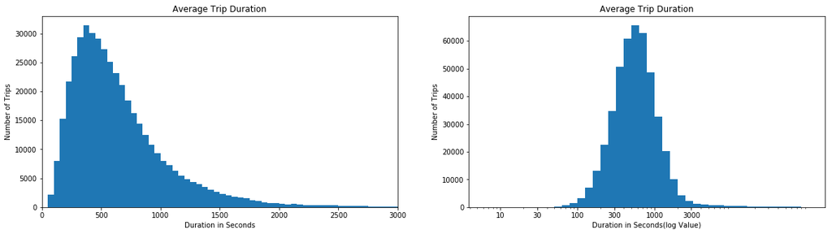

```python
plt.figure(figsize = [20,5])

# left histogram: data plotted in natural units
plt.subplot(1, 2, 1);
bin_edges = np.arange(0,df['duration_sec'].max() +50, 50)
plt.hist(data = df, x = 'duration_sec',bins = bin_edges);
plt.xlim(0,3000)
plt.xlabel('Duration in Seconds');
plt.title('Average Trip Duration');
plt.ylabel('Number of Trips');

# right histogram: data plotted after direct log transformation
plt.subplot(1, 2, 2);
bin_edges = 10 ** np.arange(0.8, np.log10(df.duration_sec.max())+0.1, 0.1);
plt.hist(df.duration_sec, bins = bin_edges);
plt.xscale('log');
tick_locs = [10, 30, 100, 300, 1000, 3000]
plt.xticks(tick_locs, tick_locs);
plt.xlabel('Duration in Seconds(log Value)');
plt.title('Average Trip Duration');
plt.ylabel('Number of Trips');
```

Since the trip duration are so skewed to right, I used a log transformation on the x-axis. Bin edges are in increments of 0.1 powers of ten with custom tick marks to demonstrate the log scaling.

To make life easy , the duration will be conveted from seconds to mintes .

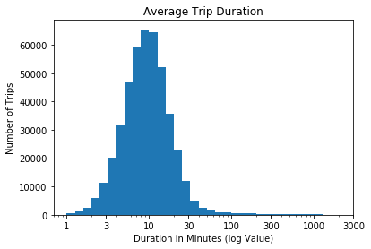

```python
# Change duration from second to minutes

df['duration_min'] = df['duration_sec'] / 60

# histogram: data plotted after direct log transformation

bin_edges = 10 ** np.arange(0, np.log10(df.duration_min.max())+0.1, 0.1)
plt.hist(df.duration_min, bins = bin_edges);
plt.xscale('log');
tick_locs = [1,3,10, 30, 100, 300, 1000, 3000]
plt.xticks(tick_locs, tick_locs);
plt.xlabel('Duration in MInutes (log Value)');
plt.title('Average Trip Duration');
plt.ylabel('Number of Trips');
```

The duration trip distribution , show that the averge duration per ride trip around 10 minutes .

### Which month has highest number of trips ?

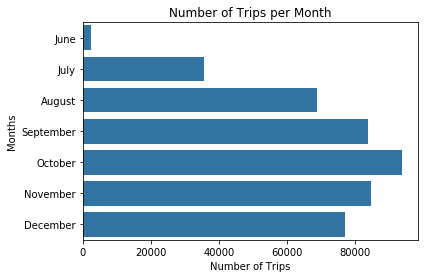

```python
# crear chart for number of trips per each month.


month_order = ['June', 'July', 'August', 'September','October','November','December']
base_color = sb.color_palette()[0]
sb.countplot(data = df, y = 'month', color = base_color , order = month_order);
plt.xlabel('Number of Trips');
plt.ylabel('Months');
plt.title('Number of Trips per Month');
```

The Bar plot shows that in October is the heighest bike trips and the fall season has more trips than Summer and first month of Winter seasons.

### Other Varibles

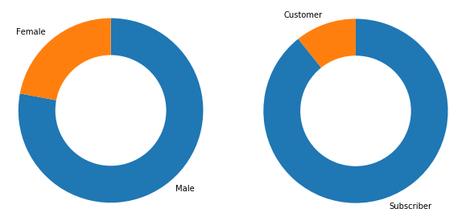

```python
# code for the donut charts for gender and User type
plt.figure(figsize = [10,5])

plt.subplot(1, 2, 1);

sorted_counts = df['member_gender'].value_counts()
plt.pie(sorted_counts, labels = sorted_counts.index, startangle = 90,
        counterclock = False, wedgeprops = {'width' : 0.4});
plt.axis('square');


plt.subplot(1, 2, 2);
sorted_counts = df['user_type'].value_counts()
plt.pie(sorted_counts, labels = sorted_counts.index, startangle = 90,
        counterclock = False, wedgeprops = {'width' : 0.4});
plt.axis('square');
```

The males and subscribera more than three quarters of the total amount.

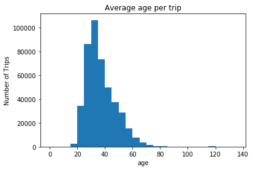

```python
# histogram to show average age .
bin_edges = np.arange(0,df['age'].max() +5, 5)
plt.hist(data = df, x = 'age',bins = bin_edges);

plt.xlabel('age');
plt.title('Average age per trip');
plt.ylabel('Number of Trips');
```

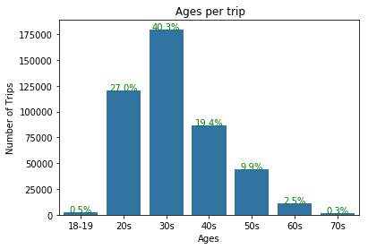

```python
# remove ages greather than 80 .

df=df[df['age'] <=80]

# add new coulnm that group the ages .

df['age_group'] = df['age'].apply(lambda x: '18-19' if 17<x<=19
                                                  else '20s' if 19<x<=29
                                                  else '30s' if 29<x<=39
                                                  else '40s' if 39<x<=49
                                                  else '50s' if 49<x<=59
                                                  else '60s' if 59<x<=69
                                                  else '70s' if 69<x<=79
                                                  else x )


# chnage data type to be in order .
df['age_group']=df.age_group.astype('category')

# plot age group .
base_color = sb.color_palette()[0]
sb.countplot(data = df, x = 'age_group', color= base_color ) ;
plt.xlabel('Ages');
plt.title(' Ages per trip');
plt.ylabel('Number of Trips');


# add annotations to show percentages for each age group .
n_trip = df.shape[0]
trip_counts = df['age_group'].value_counts()
locs, labels = plt.xticks() # get the current tick locations and labels

# loop through each pair of locations and labels
for loc, label in zip(locs, labels):

# get the text property for the label to get the correct count
     count = trip_counts[label.get_text()]
     pct_string = '{:0.1f}%'.format(100*count/n_trip);

# print the annotation just below the top of the bar
     plt.text(loc, count-8, pct_string, ha = 'center', color = 'g');
```

As you can see 30s ages ride bike more than others ages with 40.3% of all trips.

```python
df.describe()
```

|  | duration_sec | start_station_id | end_station_id | bike_id | age | duration_min |
| --- | --- | --- | --- | --- | --- | --- |
| count | 446248.000000 | 446248.000000 | 446248.000000 | 446248.000000 | 446248.000000 | 446248.000000 |
| mean | 830.646508 | 94.764582 | 91.549862 | 1680.925644 | 36.498467 | 13.844108 |
| std | 2511.993081 | 84.622124 | 83.055045 | 972.811666 | 10.193137 | 41.866551 |
| min | 61.000000 | 3.000000 | 3.000000 | 10.000000 | 18.000000 | 1.016667 |
| 25% | 364.000000 | 25.000000 | 24.000000 | 795.000000 | 29.000000 | 6.066667 |
| 50% | 556.000000 | 67.000000 | 66.000000 | 1740.000000 | 34.000000 | 9.266667 |
| 75% | 837.000000 | 137.000000 | 133.000000 | 2530.000000 | 43.000000 | 13.950000 |
| max | 86252.000000 | 340.000000 | 340.000000 | 3733.000000 | 79.000000 | 1437.533333 |

### Discuss the distribution(s) of your variable(s) of interest. Were there any unusual points? Did you need to perform any transformations?

> The distribution are highly skewed to the right with lots of points with low values, with a very long tail of data points with large values .the 75% of the data is 837 second and the maximum is 86252 seconds.It needs to apply a logarithmic transform to the data , so it will follow a normal distribution .

### Of the features you investigated, were there any unusual distributions? Did you perform any operations on the data to tidy, adjust, or change the form of the data? If so, why did you do this?

> Convert the duration from seconds to minutes senice the minutes is easier to measure the bike trip duration.

> Order the months in the Bar plot since it ordinal data type .

> Exclude outliers age greater than 80.

> Groups ages in new clounm e.g (20s,30s,40s,ect.).

## Bivariate Exploration

> In this section, investigate relationships between pairs of variables in your data. Make sure the variables that you cover here have been introduced in some fashion in the previous section (univariate exploration).

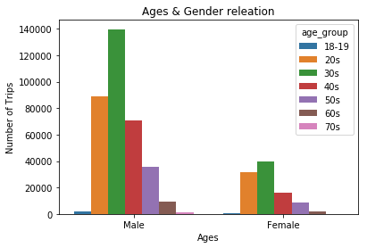

```python
# display Bar chart for two varibless.

sb.countplot(data = df, x = 'member_gender', hue = 'age_group');

plt.xlabel('Ages');
plt.title('Ages & Gender releation');
plt.ylabel('Number of Trips');
```

### Talk about some of the relationships you observed in this part of the investigation. How did the feature(s) of interest vary with other features in the dataset?

> The bar chart show the relation between the gender riders and thier ages . its shows that males ride more than females in all age groups.Furthermore, the order of ages in males is the same order in females with respect to number of trips.

## Multivariate Exploration

> Create plots of three or more variables to investigate your data even further. Make sure that your investigations are justified, and follow from your work in the previous sections.

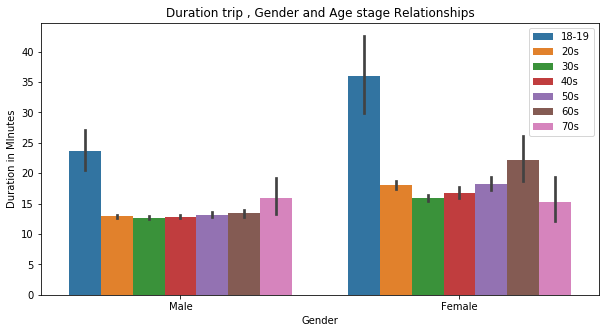

```python
# clustered bar chart using the barplot function .
plt.figure(figsize = [10,5])
g = sb.barplot(data = df, x = 'member_gender', y = 'duration_min', hue = 'age_group')
#g.legend(loc = 8, ncol = 3, framealpha = 1, title = 'User Type');

g.legend()
plt.xlabel('Gender');
plt.title('Duration trip , Gender and Age stage Relationships');
plt.ylabel('Duration in MInutes');
```

### Talk about some of the relationships you observed in this part of the investigation. Were there features that strengthened each other in terms of looking at your feature(s) of interest?

> This chart shows the relationships between 3 varibles duration per trip , gender riders and age groups . The female spend more time per trip more than the males in all age groups expect 70s. Ages 18 and 19 years old take longer trip duration than other ages in both genders. The males trips duration form 20s to 60s almost same period , while the females have disparate trips duration for same age group.

### Were there any interesting or surprising interactions between features?

> Although the males riding bikes more than females , the females spend more time in riding than the males.

> At the end of your report, make sure that you export the notebook as an html file from the `File > Download as... > HTML` menu. Make sure you keep track of where the exported file goes, so you can put it in the same folder as this notebook for project submission. Also, make sure you remove all of the quote-formatted guide notes like this one before you finish your report!

```python
# Storing clean Df to goBike_data.csv for Part2 .

df.to_csv('goBike_data.csv', index=False)
```